# Informe Grafico Feo GRUPO 26

Claudia Magliano

2023-08-11

## Introducción

Este informe se centra en los datos provenientes de la Encuesta sobre “Uso del Tiempo” realizada en la Ciudad Autónoma de Buenos Aires durante el año 2016. Dicha encuesta fue instrumentada por la Dirección General de Estadísticas y Censos del Gobierno de la Ciudad y sus resultados fueron publicados en formato abierto en 2017. (https://data.buenosaires.gob.ar/dataset/uso-tiempo) Captura información sobre distintas variables de personas residentes en CABA: sexo, edad, nivel de estudios, horas dedicadas al trabajo productivo/pago, horas dedicadas al trabajo doméstico no pago, horas dedicadas a tareas de cuidado, tipo de hogar, ingresos (por quintiles) y estado ocupacional, entre otras. Incluye datos discretos dicotómicos como el sexo y datos continuos como el tiempo para cada tarea. A partir del análisis de los datos arrojados por esta encuesta se podría ponderar la diferencia en el uso del tiempo entre varones y mujeres (sobre todo en la esfera de los cuidados), el índice de la feminización de las tareas de cuidado, etc.

## Exploración de los datos

```r
uso_tiempo_2016<-read.csv("datos/encuesta_uso_tiempo_2016.csv")
```

- ¿Qué variables tiene?
- Tiene variables cuantitativas y cualitativas
- ¿Cuántas observaciones hay?
- Hay 2336 filas (observaciones)
- ¿Cuántas variables?
- Son 27 variables

```r
uso_tiempo_2016 <- uso_tiempo_2016|>
   select(sexo,edad,trabajo_pago,trabajo_domestico_no_pago,tareas_cuidados,nivel_educativo,estado_ocupacional,recreacion,aplicaciones, estudio_educacion, rango_etario, nivel_educativo)
```

## Grafico Feo

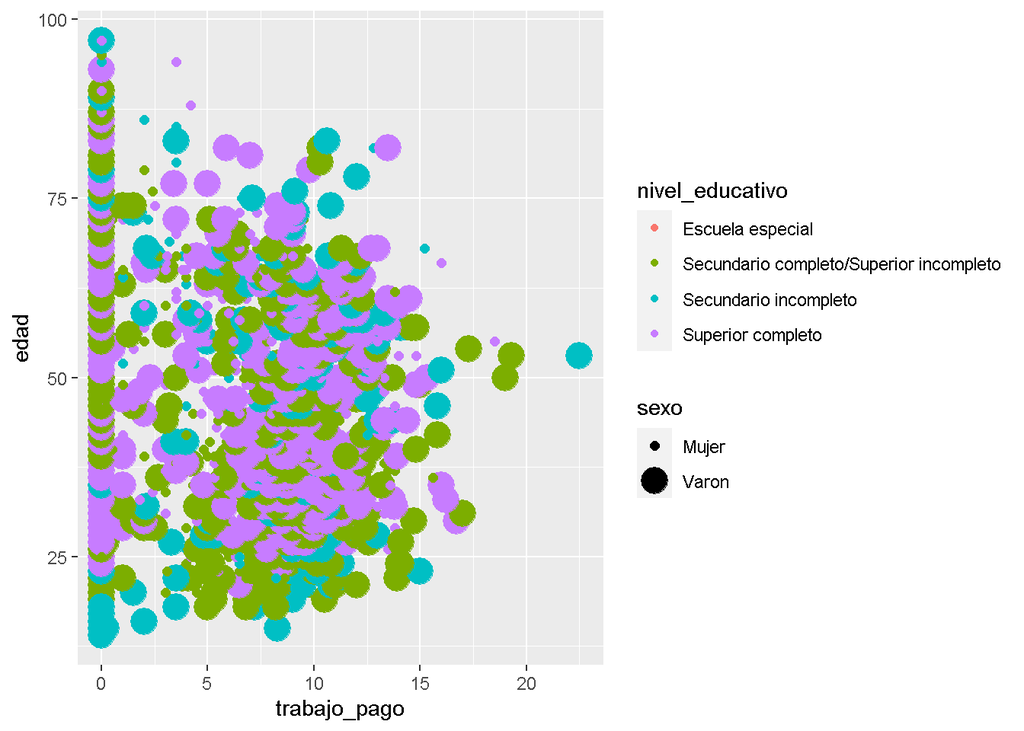

```r
ggplot(uso_tiempo_2016, aes(trabajo_pago, edad)) +
  geom_point(aes(color = nivel_educativo, size = sexo))
```

Graficamos el tiempo ocupado en trabajo remunerativo en relación a la edad, diferencian por el nivel educativo y el sexo de los individuos